# Problem statement - From LMS portal

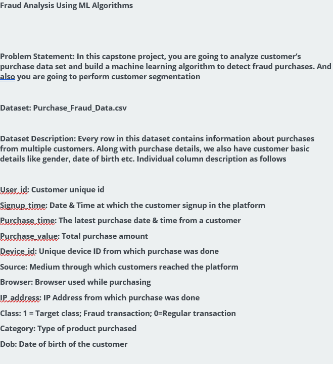

# Introduction to Fraud detection:

Typical challenges associated with fraud detection Introduction to fraud detection Types: Insurance Credit card Identity theft Money laundering Tax evasion Healthcare Product warranty e-commerce businesses must continuously assess the legitimacy of client transactions Detecting fraud is challenging: Uncommon; < 0.01% of transactions Attempts are made to conceal fraud Behavior evolves Fraudulent activities perpetrated by networks - organized crime Fraud detection requires training an algorithm to identify concealed observations from any normal observations Fraud analytics teams: Often use rules based systems, based on manually set thresholds and experience Check the news Receive external lists of fraudulent accounts and names suspicious names or track an external hit list from police to reference check against the client base Sometimes use machine learning algorithms to detect fraud or suspicious behavior Existing sources can be used as inputs into the ML model Verify the veracity of rules based labels

```python
import pandas as pd
import numpy as np
import matplotlib.pyplot as plt
import seaborn as sns
```

```python
df = pd.read_csv("Purchase_Fraud_Data.csv")
```

# 1. Data Description

```python
df.head(2)
```

|  | user_id | signup_time | purchase_time | purchase_value | device_id | source | browser | sex | ip_address | class | category | dob |
| --- | --- | --- | --- | --- | --- | --- | --- | --- | --- | --- | --- | --- |
| 0 | 22058 | 2015-02-24 22:55:49 | 2015-04-18 02:47:11 | 65278 | QVPSPJUOCKZAR | SEO | Chrome | M | 7.327584e+08 | 0 | home_essentials | 22-2-1976 |
| 1 | 333320 | 2015-06-07 20:39:50 | 2015-06-08 01:38:54 | 96399 | EOGFQPIZPYXFZ | Ads | Chrome | F | 3.503114e+08 | 0 | apparels | 2-1-1962 |

```python
df.shape
```

```
(151112, 12)
```

```python
df.dtypes
```

```
user_id             int64
signup_time        object
purchase_time      object
purchase_value      int64
device_id          object
source             object
browser            object
sex                object
ip_address        float64
class               int64
category           object
dob                object
dtype: object
```

```python
df.columns
```

```
Index(['user_id', 'signup_time', 'purchase_time', 'purchase_value',
       'device_id', 'source', 'browser', 'sex', 'ip_address', 'class',
       'category', 'dob'],
      dtype='object')
```

## 1.1 Checking Fraud to non fraud ratio

### Checking the class balance

```python
df['class'].value_counts()
```

```
0    136961
1     14151
Name: class, dtype: int64
```

```python
df['class'].value_counts(normalize=True).mul(100).round(1).astype(str) + '%'
```

```
0    90.6%
1     9.4%
Name: class, dtype: object
```

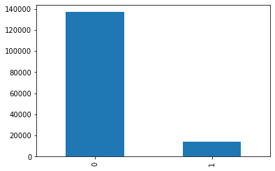

```python
df['class'].value_counts().plot(kind='bar');
```

```
This is typical real world scenario for such transactions. We will have to apply some techniques like SMOTE to handle this class imbalance
```

### 1.1.1 Handling Missing Values

```python
df.isnull().sum()
```

```
user_id              0
signup_time          0
purchase_time        0
purchase_value       0
device_id            0
source               0
browser              0
sex               4927
ip_address           0
class                0
category             0
dob               4924
dtype: int64
```

```python
df.isna().sum()/len(df)*100
```

```
user_id           0.000000
signup_time       0.000000
purchase_time     0.000000
purchase_value    0.000000
device_id         0.000000
source            0.000000
browser           0.000000
sex               3.260496
ip_address        0.000000
class             0.000000
category          0.000000
dob               3.258510
dtype: float64
```

```python
df_temp1 = df[df.sex.isna()]
```

```python
df_temp1['class'].value_counts()
```

```
0    4464
1     463
Name: class, dtype: int64
```

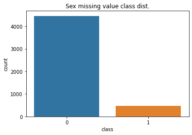

```python
sns.countplot(x='class',data = df_temp1).set(title='Sex missing value class dist.');
```

```python
df_temp2 = df[df.dob.isna()]
df_temp2['class'].value_counts()
```

```
0    4457
1     467
Name: class, dtype: int64
```

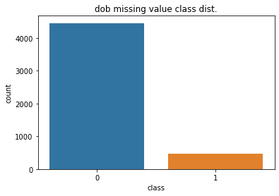

```python
sns.countplot(x='class',data = df_temp2).set(title='dob missing value class dist.');
```

### 1.1.1 Inference: Sex and dob have <5% values as missing values, droping them

```python
df = df.dropna(how = 'any', axis = 0)
df.dropna(how = 'any', axis = 0).isnull().sum()
```

```
user_id           0
signup_time       0
purchase_time     0
purchase_value    0
device_id         0
source            0
browser           0
sex               0
ip_address        0
class             0
category          0
dob               0
dtype: int64
```

## 1.2 Exploratory Data analysis

### 1.2.1 Checking for skewnes in data

```python
df.skew()
```

```
user_id           0.001247
purchase_value    0.000862
ip_address       -0.007756
class             2.789898
dtype: float64
```

### 1.2.2 Understand any obvious co-relations

```python
df.corr()
```

|  | user_id | purchase_value | ip_address | class |
| --- | --- | --- | --- | --- |
| user_id | 1.000000 | 0.002933 | -0.003462 | 0.002490 |
| purchase_value | 0.002933 | 1.000000 | -0.001130 | 0.003700 |
| ip_address | -0.003462 | -0.001130 | 1.000000 | -0.004706 |
| class | 0.002490 | 0.003700 | -0.004706 | 1.000000 |

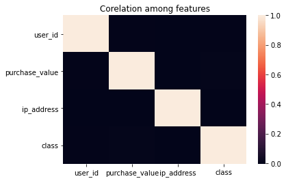

```python
sns.heatmap(df.corr()).set(title='Corelation among features');
```

### Inference: No strong co-relation between any features

### 1.2.3 Distribution of Fruad transaction w.r.t sex

```
[Text(0.5, 1.0, 'Fraud transaction Male Vs Female')]
```

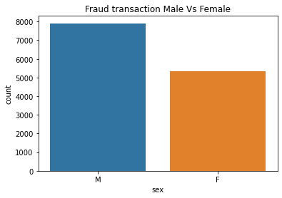

```python
sns.countplot( x = 'sex', data = df[df['class'] == 1] ).set(title='Fraud transaction Male Vs Female')
```

```python
df[(df['class'] == 1) & (df['sex'] == 'M')]['user_id'].count()
```

```
7908
```

```python
### Percentage fraudlent transaction by sex
print(" ** PERCENTAGE of Fraud transaction by \"Male\"")
df[(df['class'] == 1) & (df['sex'] == 'M')]['user_id'].count() / (len(df[df['class'] == 1]) - 4927) * 100
```

```
 ** PERCENTAGE of Fraud transaction by "Male"
```

```
95.12811259473114
```

```python
### Percentage fraudlent transaction by sex
print(" ** PERCENTAGE of Fraud transaction by \"Female\"")
df[(df['class'] == 1) & (df['sex'] == 'F')]['user_id'].count() / (len(df[df['class'] == 1]) - 4927) * 100
```

```
 ** PERCENTAGE of Fraud transaction by "Female"
```

```
64.14050282689763
```

### 1.2.3 Distribution of Fruad transaction w.r.t device used

```python
# Total number of unique devices
len(df['device_id'].unique())
```

```
129482
```

```python
len(df[df['class'] == 1]['device_id'].value_counts().unique())
```

```
18
```

```python
# Was there any device which was used more than "1 imes" for Fraud transaction
df[df['class'] == 1]['device_id'].value_counts().unique()
```

```
array([19, 17, 16, 15, 14, 13, 12, 11, 10,  9,  8,  7,  6,  5,  4,  3,  2,
        1], dtype=int64)
```

```python
df[df['class'] == 1]['device_id'].value_counts().loc[lambda x : x >= 2]
```

```
EQYVNEGOFLAWK    19
ZUSVMDEZRBDTX    19
CQTUVBYIWWWBC    19
NGQCKIADMZORL    17
FFWAQIABHGYJC    17
                 ..
YFFPJJLHEHZML     2
KNJBGEMGMWDQK     2
WGGAESLGQSMKE     2
AFLSPILWBHCWY     2
YKMVZTJLAIBNQ     2
Name: device_id, Length: 1008, dtype: int64
```

```python
df_fraud_device = df[df['class'] == 1]['device_id'].value_counts().loc[lambda x : x >= 2]
```

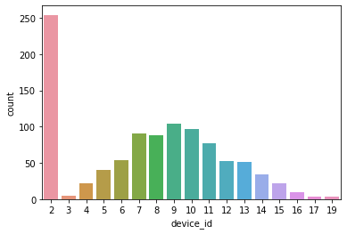

```python
sns.countplot(x= df_fraud_device.index, data= df_fraud_device);
```

```python
### Number of unique devices with more than 1 fraud transaction
len(df[df['class'] == 1]['device_id'].value_counts().loc[lambda x : x >= 2].unique())
```

```
17
```

```python
### Number of unique devices with more than 5 fraud transaction
len(df[df['class'] == 1]['device_id'].value_counts().loc[lambda x : x >= 5].unique())
```

```
14
```

### 1.2.4 Distribution of Fruad transaction w.r.t category

```python
df['category'].unique()
```

```
array(['home_essentials', 'apparels', 'electronics', 'health_care',
       'cosmetics'], dtype=object)
```

```python
df[df['class'] == 1]['category'].value_counts()
```

```
electronics        4299
health_care        2279
cosmetics          2253
apparels           2234
home_essentials    2175
Name: category, dtype: int64
```

```python
df_fraud_cateogary = df[df['class'] == 1]['category'].value_counts()
```

```python
df_fraud_cateogary= pd.DataFrame(df_fraud_cateogary)
```

```python
df_fraud_cateogary.sort_values(by='category', ascending=False)
```

|  | category |
| --- | --- |
| electronics | 4299 |
| health_care | 2279 |
| cosmetics | 2253 |
| apparels | 2234 |
| home_essentials | 2175 |

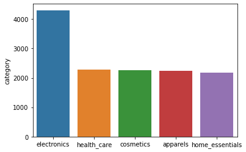

```python
sns.barplot(x =df_fraud_cateogary.index, y = df_fraud_cateogary['category'], data= df_fraud_cateogary);
```

### 1.2.4 Summary: All the categories had fraud transaction but electronics cateogary was highest

## 1.2.5 Univariate Analysis

#### 1.2.5.1 Distribution w.r.t to source

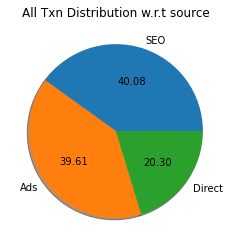

```python
x=df['source'].value_counts()
plt.pie(x,labels=x.index,autopct='%0.2f',shadow=True)
plt.title('All Txn Distribution w.r.t source')
plt.show()
```

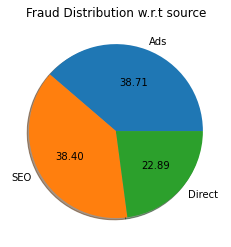

```python
x=df[df['class'] == 1]['source'].value_counts()
plt.pie(x,labels=x.index,autopct='%0.2f',shadow=True)
plt.title('Fraud Distribution w.r.t source')
plt.show()
```

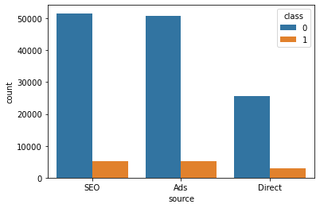

```python
sns.countplot(x='source', data = df, hue='class');
```

### Inference: SEO (highest)- > Ads -> Direct

#### 1.2.5.2 Distribution w.r.t to Gender

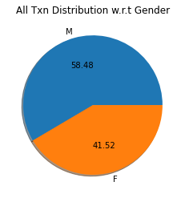

```python
x=df['sex'].value_counts()
plt.pie(x,labels=x.index,autopct='%0.2f',shadow=True)
plt.title('All Txn Distribution w.r.t Gender')
plt.show()
```

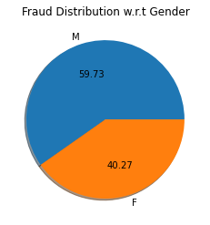

```python
x=df[df['class'] == 1]['sex'].value_counts()
plt.pie(x,labels=x.index,autopct='%0.2f',shadow=True)
plt.title('Fraud Distribution w.r.t Gender')
plt.show()
```

### Inference: Male percentage is 58% as complared to 41% for females

#### 1.2.5.3 Distribution w.r.t to browser

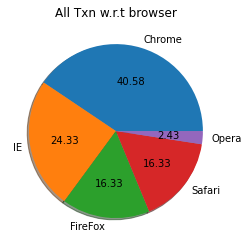

```python
x=df['browser'].value_counts()
plt.pie(x,labels=x.index,autopct='%0.2f',shadow=True)
plt.title('All Txn w.r.t browser')
plt.show()
```

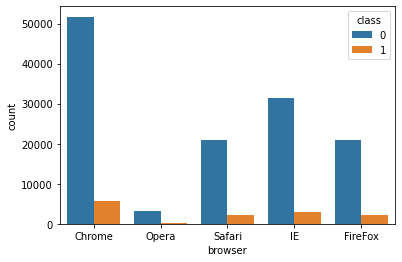

```python
sns.countplot(x='browser', data = df, hue='class')
```

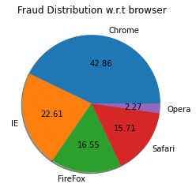

```python
x=df[df['class'] == 1]['browser'].value_counts()
plt.pie(x,labels=x.index,autopct='%0.2f',shadow=True)
plt.title('Fraud Distribution w.r.t browser')
plt.show()
```

### Inference: Browser usage Chrome -> IE -> FireFox -> Safari-> Opera

### 1.2.6 Bivariate analysis for cateogorical columns

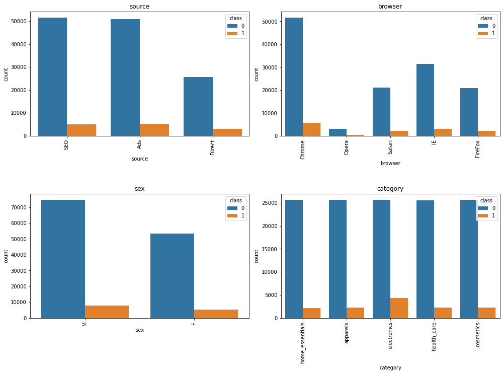

```python
col_list = ['source', 'browser', 'sex','category']
x = 3
y = 2
counter = 1
plt.figure(figsize = [14, 14])
for i in col_list:
    plt.subplot(x,y,counter)
    plt.title(i)
    sns.countplot(x=df[i],hue=df['class'])
    counter = counter+1
    plt.xticks(rotation=90)
plt.tight_layout()
plt.show()
```

### 1.2.7 Segmentation based on purchased value

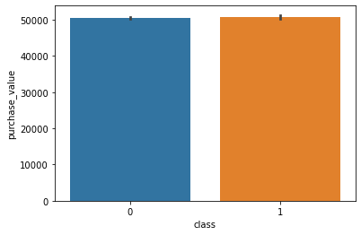

```python
sns.barplot(x = df['class'], y = df['purchase_value'])
```

```
[Text(0.5, 1.0, 'Purchase Value Vs Fraud/Regular')]
```

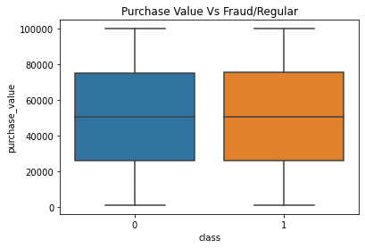

```python
sns.boxplot(x= df['class'], y = df['purchase_value']).set(title='Purchase Value Vs Fraud/Regular')
```

### Inference: Both fraud and non fraud transactiations were in same purchase value range

### 1.2.7 Binning purchase value into multiple cateogories "

```python
df['purchase_bins'] = pd.cut(df['purchase_value'],
                             bins=[df['purchase_value'].min(), 10000, 20000, 50000, df['purchase_value'].max()],
                             labels = ['pur_val_10k','pur_val_20k',
                                       'pur_val_50k','pur_val_max'])
```

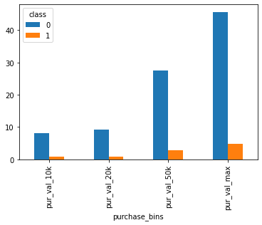

```python
(pd.crosstab(df['purchase_bins'],df['class'],normalize=True)*100).plot(kind="bar")
plt.show()
```

```python
df['purchase_bins'].value_counts()
```

```
pur_val_max    71360
pur_val_50k    43045
pur_val_20k    14252
pur_val_10k    12746
Name: purchase_bins, dtype: int64
```

### Inference: Highest number of Valid transactions beween 50K - Max value, Fraud transaction is also higher in this range

# 1.3 Data Pre-Processing

```python
df.dtypes
```

```
user_id              int64
signup_time         object
purchase_time       object
purchase_value       int64
device_id           object
source              object
browser             object
sex                 object
ip_address         float64
class                int64
category            object
dob                 object
purchase_bins     category
dtype: object
```

```python
df.head(2)
```

|  | user_id | signup_time | purchase_time | purchase_value | device_id | source | browser | sex | ip_address | class | category | dob | purchase_bins |
| --- | --- | --- | --- | --- | --- | --- | --- | --- | --- | --- | --- | --- | --- |
| 0 | 22058 | 2015-02-24 22:55:49 | 2015-04-18 02:47:11 | 65278 | QVPSPJUOCKZAR | SEO | Chrome | M | 7.327584e+08 | 0 | home_essentials | 22-2-1976 | pur_val_max |
| 1 | 333320 | 2015-06-07 20:39:50 | 2015-06-08 01:38:54 | 96399 | EOGFQPIZPYXFZ | Ads | Chrome | F | 3.503114e+08 | 0 | apparels | 2-1-1962 | pur_val_max |

### 1.3.1 Parsing dates as datetime

```python
df['signup_time'] = pd.to_datetime(df['signup_time'])
df['purchase_time'] = pd.to_datetime(df['purchase_time'])
```

```python
df.dtypes
```

```
user_id                    int64
signup_time       datetime64[ns]
purchase_time     datetime64[ns]
purchase_value             int64
device_id                 object
source                    object
browser                   object
sex                       object
ip_address               float64
class                      int64
category                  object
dob                       object
purchase_bins           category
dtype: object
```

### 1.3.2 Handling IP address

- We will first convert IP numbers to IPv4 format
- Use ipapi: will help us fetch location information for a particular IP address

```python
# importing the module
import ipaddress

# converting int to IPv4 address
def num_to_ip(ip_addr):
    return ipaddress.ip_address(ip_addr)
```

```python
df['ipv4'] = df['ip_address'].astype('int64').abs().apply(num_to_ip)
```

```python
df.head(2)
```

|  | user_id | signup_time | purchase_time | purchase_value | device_id | source | browser | sex | ip_address | class | category | dob | purchase_bins | ipv4 |
| --- | --- | --- | --- | --- | --- | --- | --- | --- | --- | --- | --- | --- | --- | --- |
| 0 | 22058 | 2015-02-24 22:55:49 | 2015-04-18 02:47:11 | 65278 | QVPSPJUOCKZAR | SEO | Chrome | M | 7.327584e+08 | 0 | home_essentials | 22-2-1976 | pur_val_max | 43.173.1.96 |
| 1 | 333320 | 2015-06-07 20:39:50 | 2015-06-08 01:38:54 | 96399 | EOGFQPIZPYXFZ | Ads | Chrome | F | 3.503114e+08 | 0 | apparels | 2-1-1962 | pur_val_max | 20.225.83.219 |

```python
import requests

def get_location(ip_address):

    response = requests.get(f'https://ipapi.co/{ip_address}/json/').json()
    location_data = {
        #"ip": ip_address,
        "city": response.get("city"),
        "region": response.get("region"),
        "country": response.get("country_name")
    }
    return location_data
```

### Taking lot of time- Tried overnight but failed . This is an optimization that can be done later

```python
#df['ipv4_city'] = df['ipv4'].apply(get_location)['city']
```

# 1.4 Feature Engineering

### 1.4.1 Adding a new column which will be the difference between signup time and purchase time

```python
df['purchase_singup_diff'] = df['purchase_time'] - df['signup_time']
```

```python
df.head(2)
```

|  | user_id | signup_time | purchase_time | purchase_value | device_id | source | browser | sex | ip_address | class | category | dob | purchase_bins | ipv4 | purchase_singup_diff |
| --- | --- | --- | --- | --- | --- | --- | --- | --- | --- | --- | --- | --- | --- | --- | --- |
| 0 | 22058 | 2015-02-24 22:55:49 | 2015-04-18 02:47:11 | 65278 | QVPSPJUOCKZAR | SEO | Chrome | M | 7.327584e+08 | 0 | home_essentials | 22-2-1976 | pur_val_max | 43.173.1.96 | 52 days 03:51:22 |
| 1 | 333320 | 2015-06-07 20:39:50 | 2015-06-08 01:38:54 | 96399 | EOGFQPIZPYXFZ | Ads | Chrome | F | 3.503114e+08 | 0 | apparels | 2-1-1962 | pur_val_max | 20.225.83.219 | 0 days 04:59:04 |

### Coverting the time diff into minutes

```python
df['purchase_singup_diff_min'] = df['purchase_singup_diff'].dt.total_seconds()/60
```

```python
df.head(2)
```

|  | user_id | signup_time | purchase_time | purchase_value | device_id | source | browser | sex | ip_address | class | category | dob | purchase_bins | ipv4 | purchase_singup_diff | purchase_singup_diff_min |
| --- | --- | --- | --- | --- | --- | --- | --- | --- | --- | --- | --- | --- | --- | --- | --- | --- |
| 0 | 22058 | 2015-02-24 22:55:49 | 2015-04-18 02:47:11 | 65278 | QVPSPJUOCKZAR | SEO | Chrome | M | 7.327584e+08 | 0 | home_essentials | 22-2-1976 | pur_val_max | 43.173.1.96 | 52 days 03:51:22 | 75111.366667 |
| 1 | 333320 | 2015-06-07 20:39:50 | 2015-06-08 01:38:54 | 96399 | EOGFQPIZPYXFZ | Ads | Chrome | F | 3.503114e+08 | 0 | apparels | 2-1-1962 | pur_val_max | 20.225.83.219 | 0 days 04:59:04 | 299.066667 |

```python
### Coverting the time diff into hrs --> NOT using it
# df['purchase_singup_diff_hrs'] = df['purchase_singup_diff'].astype('timedelta64[h]')
```

### 1.4.3 Converting purchase time to month, day, hour ( Deliberatly dropping minute and year)

```python
df['purchase_month'] = df['purchase_time'].dt.month
df['purchase_day'] = df['purchase_time'].dt.day
#df['purchase_hour'] = df['purchase_time'].dt.hour # -> not using it in first iteration
```

#### 1.4.3.1 Convert month number to month name(will be using one hot encoding later)

```python
import calendar
df['Month'] = df['purchase_month'].apply(lambda x: calendar.month_abbr[x])
```

```python
df.head()
```

|  | user_id | signup_time | purchase_time | purchase_value | device_id | source | browser | sex | ip_address | class | category | dob | purchase_bins | ipv4 | purchase_singup_diff | purchase_singup_diff_min | purchase_month | purchase_day | Month |
| --- | --- | --- | --- | --- | --- | --- | --- | --- | --- | --- | --- | --- | --- | --- | --- | --- | --- | --- | --- |
| 0 | 22058 | 2015-02-24 22:55:49 | 2015-04-18 02:47:11 | 65278 | QVPSPJUOCKZAR | SEO | Chrome | M | 7.327584e+08 | 0 | home_essentials | 22-2-1976 | pur_val_max | 43.173.1.96 | 52 days 03:51:22 | 75111.366667 | 4 | 18 | Apr |
| 1 | 333320 | 2015-06-07 20:39:50 | 2015-06-08 01:38:54 | 96399 | EOGFQPIZPYXFZ | Ads | Chrome | F | 3.503114e+08 | 0 | apparels | 2-1-1962 | pur_val_max | 20.225.83.219 | 0 days 04:59:04 | 299.066667 | 6 | 8 | Jun |
| 2 | 1359 | 2015-01-01 18:52:44 | 2015-01-01 18:52:45 | 57296 | YSSKYOSJHPPLJ | SEO | Opera | M | 2.621474e+09 | 1 | electronics | 5-3-1962 | pur_val_max | 156.64.132.28 | 0 days 00:00:01 | 0.016667 | 1 | 1 | Jan |
| 3 | 150084 | 2015-04-28 21:13:25 | 2015-05-04 13:54:50 | 43650 | ATGTXKYKUDUQN | SEO | Safari | M | 3.840542e+09 | 0 | health_care | 3-7-1974 | pur_val_50k | 228.234.6.235 | 5 days 16:41:25 | 8201.416667 | 5 | 4 | May |
| 4 | 221365 | 2015-07-21 07:09:52 | 2015-09-09 18:40:53 | 45016 | NAUITBZFJKHWW | Ads | Safari | M | 4.155831e+08 | 0 | home_essentials | 25-8-1970 | pur_val_50k | 24.197.75.141 | 50 days 11:31:01 | 72691.016667 | 9 | 9 | Sep |

### 1.4.4 Marking the device as dirty(where fraudulent transaction was reported) and not dirty

```python
def device_tag(df):
    if (df['class'] == 1):
        return 1
    else:
        return 0
df["device_dirty"] = df.apply(device_tag, axis=1)
```

```python
from math import pi

def day_radian(df):
    day_coeff = 31/(2*pi)
    return df['purchase_day']*day_coeff

df['purchase_day_radian'] = df.apply(day_radian, axis=1)
```

# 1.5 Preparing (Pre-model Generation) Data Set

```python
df.head()
```

|  | user_id | signup_time | purchase_time | purchase_value | device_id | source | browser | sex | ip_address | class | ... | dob | purchase_bins | ipv4 | purchase_singup_diff | purchase_singup_diff_min | purchase_month | purchase_day | Month | device_dirty | purchase_day_radian |
| --- | --- | --- | --- | --- | --- | --- | --- | --- | --- | --- | --- | --- | --- | --- | --- | --- | --- | --- | --- | --- | --- |
| 0 | 22058 | 2015-02-24 22:55:49 | 2015-04-18 02:47:11 | 65278 | QVPSPJUOCKZAR | SEO | Chrome | M | 7.327584e+08 | 0 | ... | 22-2-1976 | pur_val_max | 43.173.1.96 | 52 days 03:51:22 | 75111.366667 | 4 | 18 | Apr | 0 | 88.808458 |
| 1 | 333320 | 2015-06-07 20:39:50 | 2015-06-08 01:38:54 | 96399 | EOGFQPIZPYXFZ | Ads | Chrome | F | 3.503114e+08 | 0 | ... | 2-1-1962 | pur_val_max | 20.225.83.219 | 0 days 04:59:04 | 299.066667 | 6 | 8 | Jun | 0 | 39.470426 |
| 2 | 1359 | 2015-01-01 18:52:44 | 2015-01-01 18:52:45 | 57296 | YSSKYOSJHPPLJ | SEO | Opera | M | 2.621474e+09 | 1 | ... | 5-3-1962 | pur_val_max | 156.64.132.28 | 0 days 00:00:01 | 0.016667 | 1 | 1 | Jan | 1 | 4.933803 |
| 3 | 150084 | 2015-04-28 21:13:25 | 2015-05-04 13:54:50 | 43650 | ATGTXKYKUDUQN | SEO | Safari | M | 3.840542e+09 | 0 | ... | 3-7-1974 | pur_val_50k | 228.234.6.235 | 5 days 16:41:25 | 8201.416667 | 5 | 4 | May | 0 | 19.735213 |
| 4 | 221365 | 2015-07-21 07:09:52 | 2015-09-09 18:40:53 | 45016 | NAUITBZFJKHWW | Ads | Safari | M | 4.155831e+08 | 0 | ... | 25-8-1970 | pur_val_50k | 24.197.75.141 | 50 days 11:31:01 | 72691.016667 | 9 | 9 | Sep | 0 | 44.404229 |

5 rows × 21 columns

```python
df.columns
```

```
Index(['user_id', 'signup_time', 'purchase_time', 'purchase_value',
       'device_id', 'source', 'browser', 'sex', 'ip_address', 'class',
       'category', 'dob', 'purchase_bins', 'ipv4', 'purchase_singup_diff',
       'purchase_singup_diff_min', 'purchase_month', 'purchase_day', 'Month',
       'device_dirty', 'purchase_day_radian'],
      dtype='object')
```

### 1.5.1 Deleting following columns

- 'user_id',
- 'signup_time',
- 'purchase_time',
- 'device_id'
- 'ip_address',
- 'dob',
- 'purchase_bins',
- 'purchase_singup_diff',
- 'purchase_month'
- 'purchase_day'
- 'ipv4' # will handle this later if the API works

```python
df = df.drop(columns=['user_id', 'signup_time', 'purchase_time','purchase_bins', 'device_id', 'ip_address', 'dob', 'purchase_singup_diff','purchase_month', 'purchase_day', 'ipv4'], axis=1)
```

```python
df.head()
```

|  | purchase_value | source | browser | sex | class | category | purchase_singup_diff_min | Month | device_dirty | purchase_day_radian |
| --- | --- | --- | --- | --- | --- | --- | --- | --- | --- | --- |
| 0 | 65278 | SEO | Chrome | M | 0 | home_essentials | 75111.366667 | Apr | 0 | 88.808458 |
| 1 | 96399 | Ads | Chrome | F | 0 | apparels | 299.066667 | Jun | 0 | 39.470426 |
| 2 | 57296 | SEO | Opera | M | 1 | electronics | 0.016667 | Jan | 1 | 4.933803 |
| 3 | 43650 | SEO | Safari | M | 0 | health_care | 8201.416667 | May | 0 | 19.735213 |
| 4 | 45016 | Ads | Safari | M | 0 | home_essentials | 72691.016667 | Sep | 0 | 44.404229 |

### 1.5.2 Checking the dataframe

```python
df.shape
```

```
(141404, 10)
```

```python
df.columns
```

```
Index(['purchase_value', 'source', 'browser', 'sex', 'class', 'category',
       'purchase_singup_diff_min', 'Month', 'device_dirty',
       'purchase_day_radian'],
      dtype='object')
```

```python
# Ordering all cateogorical columns together
df = df.iloc[:,[0,1,2,3,5,7,6,8,9,4]]
```

```python
df.dtypes
```

```
purchase_value                int64
source                       object
browser                      object
sex                          object
category                     object
Month                        object
purchase_singup_diff_min    float64
device_dirty                  int64
purchase_day_radian         float64
class                         int64
dtype: object
```

```python
df.head()
```

|  | purchase_value | source | browser | sex | category | Month | purchase_singup_diff_min | device_dirty | purchase_day_radian | class |
| --- | --- | --- | --- | --- | --- | --- | --- | --- | --- | --- |
| 0 | 65278 | SEO | Chrome | M | home_essentials | Apr | 75111.366667 | 0 | 88.808458 | 0 |
| 1 | 96399 | Ads | Chrome | F | apparels | Jun | 299.066667 | 0 | 39.470426 | 0 |
| 2 | 57296 | SEO | Opera | M | electronics | Jan | 0.016667 | 1 | 4.933803 | 1 |
| 3 | 43650 | SEO | Safari | M | health_care | May | 8201.416667 | 0 | 19.735213 | 0 |
| 4 | 45016 | Ads | Safari | M | home_essentials | Sep | 72691.016667 | 0 | 44.404229 | 0 |

```python
# Map "Male" to 1 and female to 0
# Hot encodong was failing for 3 columns together

df['sex'] = df['sex'].map(lambda x : 1 if x == 'M' else 0)
```

```python
df.head(2)
```

|  | purchase_value | source | browser | sex | category | Month | purchase_singup_diff_min | device_dirty | purchase_day_radian | class |
| --- | --- | --- | --- | --- | --- | --- | --- | --- | --- | --- |
| 0 | 65278 | SEO | Chrome | 1 | home_essentials | Apr | 75111.366667 | 0 | 88.808458 | 0 |
| 1 | 96399 | Ads | Chrome | 0 | apparels | Jun | 299.066667 | 0 | 39.470426 | 0 |

# Cateogorical variables encoding

```python
from sklearn.preprocessing import OneHotEncoder
from sklearn.compose import ColumnTransformer
from sklearn import preprocessing
```

```python
# Listing all the cateogorical columns
cat = df.select_dtypes(include='O').keys()
cat
```

```
Index(['source', 'browser', 'category', 'Month'], dtype='object')
```

```python
for x in df.columns:
    #printing unique values
    print(x ,':', len(df[x].unique()))
```

```
purchase_value : 75216
source : 3
browser : 5
sex : 2
category : 5
Month : 12
purchase_singup_diff_min : 132479
device_dirty : 2
purchase_day_radian : 31
class : 2
```

```python
X = df.drop(['class'], axis = 1)
y = df['class']
```

```python
cat_columnTransformer = ColumnTransformer([('encoder', OneHotEncoder(), [1,2,4,5])], remainder='passthrough')
X = np.array(cat_columnTransformer.fit_transform(X))
```

```python
X.shape
```

```
(141404, 30)
```

```python
df.head()
```

|  | purchase_value | source | browser | sex | category | Month | purchase_singup_diff_min | device_dirty | purchase_day_radian | class |
| --- | --- | --- | --- | --- | --- | --- | --- | --- | --- | --- |
| 0 | 65278 | SEO | Chrome | 1 | home_essentials | Apr | 75111.366667 | 0 | 88.808458 | 0 |
| 1 | 96399 | Ads | Chrome | 0 | apparels | Jun | 299.066667 | 0 | 39.470426 | 0 |
| 2 | 57296 | SEO | Opera | 1 | electronics | Jan | 0.016667 | 1 | 4.933803 | 1 |
| 3 | 43650 | SEO | Safari | 1 | health_care | May | 8201.416667 | 0 | 19.735213 | 0 |
| 4 | 45016 | Ads | Safari | 1 | home_essentials | Sep | 72691.016667 | 0 | 44.404229 | 0 |

### 1.5.3 Separating X(features) and Y(target) values

```python
### Features just before conversion to array
df.head(1)
```

|  | purchase_value | source | browser | sex | category | Month | purchase_singup_diff_min | device_dirty | purchase_day_radian | class |
| --- | --- | --- | --- | --- | --- | --- | --- | --- | --- | --- |
| 0 | 65278 | SEO | Chrome | 1 | home_essentials | Apr | 75111.366667 | 0 | 88.808458 | 0 |

```python
print(X.shape, y.shape)
```

```
(141404, 30) (141404,)
```

### 1.5.4 Train and test split

```python
from sklearn.model_selection import train_test_split
X_Train, X_Test, y_Train, y_Test = train_test_split(X, y, test_size = 0.2, random_state = 42)
```

```python
print(X_Train.shape, X_Test.shape, y_Train.shape, y_Test.shape)
```

```
(113123, 30) (28281, 30) (113123,) (28281,)
```

### Percentatge of fraud samples in Train data

```python
print( len(y_Train[y_Train == 1])/ len(y_Train) * 100)
```

```
9.279280075669845
```

### Percentatge of fraud samples in Test data

```python
print( len(y_Test[y_Test == 1])/ len(y_Test) * 100)
```

```
9.699091262685194
```

## 1.6 Building the first model

## Logistic Regression (without SMOTE)

```python
from sklearn.linear_model import LogisticRegression
```

```python
log_reg = LogisticRegression(solver='lbfgs')
log_reg_model=log_reg.fit(X_Train, y_Train)
y_pred = log_reg_model.predict(X_Test)
```

```python
from sklearn.metrics import confusion_matrix, classification_report
```

```python
cm_log_reg_model = confusion_matrix(y_Test, y_pred)
cm_log_reg_model
```

```
array([[25428,   110],
       [   27,  2716]], dtype=int64)
```

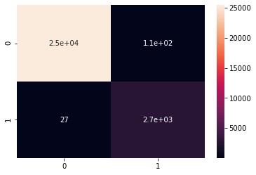

```python
sns.heatmap(cm_log_reg_model, annot=True);
```

```python
cr_log_reg_model = classification_report(y_Test, y_pred)
print(cr_log_reg_model)
```

```
              precision    recall  f1-score   support

           0       1.00      1.00      1.00     25538
           1       0.96      0.99      0.98      2743

    accuracy                           1.00     28281
   macro avg       0.98      0.99      0.99     28281
weighted avg       1.00      1.00      1.00     28281
```

### 1.6.1 Accuracy on training Data

```python
y_pred_ontrain = log_reg_model.predict(X_Train)
cr_log_reg_model_train = classification_report(y_Train, y_pred_ontrain)
print(cr_log_reg_model_train)
```

```
              precision    recall  f1-score   support

           0       1.00      1.00      1.00    102626
           1       0.97      0.99      0.98     10497

    accuracy                           1.00    113123
   macro avg       0.98      0.99      0.99    113123
weighted avg       1.00      1.00      1.00    113123
```

```python
print('Logistic Regression Train score(mean accuracy) without SMOTE ',log_reg_model.score(X_Train,y_Train) ,'\n')
print('Logistic Regression Test score(mean accuracy) without SMOTE ',log_reg_model.score(X_Test,y_Test))
```

```
Logistic Regression Train score(mean accuracy) without SMOTE  0.9960043492481635

Logistic Regression Test score(mean accuracy) without SMOTE  0.9951557582829461
```

### Logistic Regression : Accuracy on Training Data 99.6% , Accuracy on Test Data 99.5%

### 1.6.2 Using SMOTE to balance the class

```python
#pip install -U imbalanced-learn
```

```python
from imblearn import under_sampling, over_sampling
from imblearn.over_sampling import SMOTE
sm = SMOTE()
X_Train_sm, y_Train_sm= sm.fit_resample(X_Train, y_Train.astype('int'))
```

### Samples before SMOTE

```python
y_Train.value_counts()
```

```
0    102626
1     10497
Name: class, dtype: int64
```

### Samples after SMOTE

```python
y_Train_sm.value_counts()
```

```
0    102626
1    102626
Name: class, dtype: int64
```

### Apply LogisticRegression model

```python
lr_with_smote = LogisticRegression(random_state=20,solver='liblinear')
lr_model_with_smote = lr_with_smote.fit(X_Train_sm, y_Train_sm)

y_pred_smote=lr_model_with_smote.predict(X_Test)

print(classification_report(y_Test,y_pred_smote))
```

```
              precision    recall  f1-score   support

           0       0.97      0.76      0.85     25538
           1       0.25      0.75      0.37      2743

    accuracy                           0.76     28281
   macro avg       0.61      0.75      0.61     28281
weighted avg       0.90      0.76      0.80     28281
```

```python
print('Logistic Regression Train score(mean accuracy) with SMOTE',lr_model_with_smote.score(X_Train_sm,y_Train_sm) ,'\n')
print('Logistic Regression Test score(mean accuracy) with SMOTE ',lr_model_with_smote.score(X_Test,y_Test))
```

```
Logistic Regression Train score(mean accuracy) with SMOTE 0.7563775261629606

Logistic Regression Test score(mean accuracy) with SMOTE  0.7567271312895584
```

### Logistic Regression : Accuracy on Training Data 75.5% , Accuracy on Test Data 75.6%

## 1.6.3 Using Descision Tree

#### 1.6.3.1 Descision Tree without SMOTE

```python
from sklearn.tree import DecisionTreeClassifier
d_tree = DecisionTreeClassifier(random_state=10)
d_tree_model=d_tree.fit(X_Train,y_Train)
```

```python
y_pred_d_tree = d_tree_model.predict(X_Test)
```

```python
print(classification_report(y_Test,y_pred_d_tree))
```

```
              precision    recall  f1-score   support

           0       1.00      1.00      1.00     25538
           1       1.00      1.00      1.00      2743

    accuracy                           1.00     28281
   macro avg       1.00      1.00      1.00     28281
weighted avg       1.00      1.00      1.00     28281
```

```python
print('Descision Tree: Train score(mean accuracy) without SMOTE',d_tree_model.score(X_Train,y_Train) ,'\n')
print('Descision Tree: Test score(mean accuracy) without SMOTE ',d_tree_model.score(X_Test,y_Test))
```

```
Descision Tree: Train score(mean accuracy) without SMOTE 1.0

Descision Tree: Test score(mean accuracy) without SMOTE  1.0
```

### Descision tree on Train data

```python
y_pred_ontrain = d_tree_model.predict(X_Train)
dtree_log_reg_model_train = classification_report(y_Train, y_pred_ontrain)
print(dtree_log_reg_model_train)
```

```
              precision    recall  f1-score   support

           0       1.00      1.00      1.00    102626
           1       1.00      1.00      1.00     10497

    accuracy                           1.00    113123
   macro avg       1.00      1.00      1.00    113123
weighted avg       1.00      1.00      1.00    113123
```

#### 1.6.3.1 Descision Tree "with" SMOTE

```python
from sklearn.tree import DecisionTreeClassifier
d_tree_sm = DecisionTreeClassifier(random_state=10)
d_tree_model_with_smote=d_tree_sm.fit(X_Train_sm,y_Train_sm)
```

```python
y_pred_d_tree_sm = d_tree_model_with_smote.predict(X_Test)
```

```python
print(classification_report(y_Test,y_pred_d_tree_sm))
```

```
              precision    recall  f1-score   support

           0       1.00      1.00      1.00     25538
           1       1.00      1.00      1.00      2743

    accuracy                           1.00     28281
   macro avg       1.00      1.00      1.00     28281
weighted avg       1.00      1.00      1.00     28281
```

```python
print('Descision Tree: Train score(mean accuracy) with SMOTE',d_tree_model.score(X_Train_sm,y_Train_sm) ,'\n')
print('Descision Tree: Test score(mean accuracy) with SMOTE ',d_tree_model.score(X_Test,y_Test))
```

```
Descision Tree: Train score(mean accuracy) with SMOTE 1.0

Descision Tree: Test score(mean accuracy) with SMOTE  1.0
```

## 1.6.4 Using Random forest

```python
from sklearn.ensemble import GradientBoostingClassifier,RandomForestClassifier
rand_forest_classifier=RandomForestClassifier(random_state=10)
rand_forest_classifier_model=rand_forest_classifier.fit(X_Train_sm,y_Train_sm)
```

```python
y_pred_rfc_sm=rand_forest_classifier_model.predict(X_Test)
```

```python
print(classification_report(y_Test,y_pred_rfc_sm))
```

```
              precision    recall  f1-score   support

           0       1.00      1.00      1.00     25538
           1       1.00      1.00      1.00      2743

    accuracy                           1.00     28281
   macro avg       1.00      1.00      1.00     28281
weighted avg       1.00      1.00      1.00     28281
```

```python
print('Randon Forest Tree: Train score with SMOTE',rand_forest_classifier_model.score(X_Train_sm,y_Train_sm) ,'\n')
print('Randon Forest Tree: Test score with SMOTE ',rand_forest_classifier_model.score(X_Test,y_Test))
```

```
Randon Forest Tree: Train score with SMOTE 1.0

Randon Forest Tree: Test score with SMOTE  1.0
```

### Random forest model on training data

```python
y_pred_ontrain = rand_forest_classifier.predict(X_Train)
dtree_rand_f_model_train = classification_report(y_Train, y_pred_ontrain)
print(dtree_rand_f_model_train)
```

```
              precision    recall  f1-score   support

           0       1.00      1.00      1.00    102626
           1       1.00      1.00      1.00     10497

    accuracy                           1.00    113123
   macro avg       1.00      1.00      1.00    113123
weighted avg       1.00      1.00      1.00    113123
```

## 1.6.5 Artificical Neural Network

```python
import tensorflow as tf
```

```python
ann = tf.keras.models.Sequential()
ann.add(tf.keras.layers.Dense(units=32, activation='relu'))
```

```python
ann.add(tf.keras.layers.Dense(units=32, activation='relu'))
```

```python
ann.add(tf.keras.layers.Dense(units=32, activation='relu'))
```

```python
ann.add(tf.keras.layers.Dense(units=1, activation='sigmoid'))
```

```python
ann.compile(optimizer='adam', loss='binary_crossentropy', metrics=['accuracy'])
```

```python
ann.fit(X_Train, y_Train, batch_size=32, epochs=20)
```

```
<keras.callbacks.History at 0x260bfe51ca0>
```

```python
ann.summary()
```

```
Model: "sequential"
_________________________________________________________________
 Layer (type)                Output Shape              Param #
=================================================================
 dense (Dense)               (None, 32)                992

 dense_1 (Dense)             (None, 32)                1056

 dense_2 (Dense)             (None, 32)                1056

 dense_3 (Dense)             (None, 1)                 33

=================================================================
Total params: 3,137
Trainable params: 3,137
Non-trainable params: 0
_________________________________________________________________
```

```python
y_pred_ann_interim = ann.predict(X_Test)
y_pred_ann = (y_pred_ann_interim > 0.5)
```

```python
print(classification_report(y_Test,y_pred_ann))
```

```
              precision    recall  f1-score   support

           0       0.96      0.99      0.98     25538
           1       0.91      0.66      0.77      2743

    accuracy                           0.96     28281
   macro avg       0.94      0.83      0.87     28281
weighted avg       0.96      0.96      0.96     28281
```

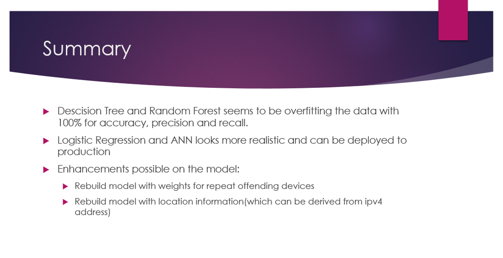